```python
%matplotlib inline
import geopandas as gpd
import pandas as pd
import matplotlib.pyplot as plt
import numpy as np
```

# Import Shapefiles

No shapefile was available for all Southeast and South Asian countries at the province level, so let's download them separately and concat later.

```python
Bangladesh_geodf = gpd.read_file("BGD_adm_shp/BGD_adm1.shp")
Bangladesh_geodf['coords'] = Bangladesh_geodf['geometry'].apply(lambda x: x.representative_point().coords[:])
Bangladesh_geodf['coords'] = [coords[0] for coords in Bangladesh_geodf['coords']]
Bangladesh_geodf.head()
```

|  | CCA_1 | CCN_1 | ENGTYPE_1 | HASC_1 | ID_0 | ID_1 | ISO | NAME_0 | NAME_1 | NL_NAME_1 | TYPE_1 | VARNAME_1 | geometry | coords |
| --- | --- | --- | --- | --- | --- | --- | --- | --- | --- | --- | --- | --- | --- | --- |
| 0 | None | 0 | Division | BD.BA | 20 | 1 | BGD | Bangladesh | Barisal | None | Bibhag | Bakerganj | (POLYGON ((90.59583282470732 21.73779106140142... | (90.08694673254791, 22.507297515869226) |
| 1 | None | 0 | Division | BD.CG | 20 | 2 | BGD | Bangladesh | Chittagong | None | Bibhag | Chattagram\|Parbattya Chattagram\|Rangamati | (POLYGON ((92.27416992187494 20.92611122131353... | (92.12255656808205, 22.505138397216825) |
| 2 | None | 0 | Division | BD.DA | 20 | 3 | BGD | Bangladesh | Dhaka | None | Bibhag | Daca\|Dacca | (POLYGON ((90.53539276123075 23.05745887756359... | (90.41773081695224, 24.12462520599368) |
| 3 | None | 0 | Division | BD.KH | 20 | 4 | BGD | Bangladesh | Khulna | None | Bibhag | None | (POLYGON ((89.23109436035179 21.70012092590338... | (89.33294352171342, 23.145980834960938) |
| 4 | None | 0 | Division | BD.RS | 20 | 5 | BGD | Bangladesh | Rajshahi | None | Bibhag | None | POLYGON ((88.99384307861334 25.27587127685558,... | (88.93052378483573, 24.538715362548885) |

```python
India_geodf = gpd.read_file("IND_adm_shp/IND_adm1.shp")
India_geodf['coords'] = India_geodf['geometry'].apply(lambda x: x.representative_point().coords[:])
India_geodf['coords'] = [coords[0] for coords in India_geodf['coords']]
India_geodf.head()
```

|  | CCA_1 | CCN_1 | ENGTYPE_1 | HASC_1 | ID_0 | ID_1 | ISO | NAME_0 | NAME_1 | NL_NAME_1 | TYPE_1 | VARNAME_1 | geometry | coords |
| --- | --- | --- | --- | --- | --- | --- | --- | --- | --- | --- | --- | --- | --- | --- |
| 0 | None | 0 | Union Territory | IN.AN | 105 | 1 | IND | India | Andaman and Nicobar | None | Union Territor | Andaman & Nicobar Islands\|Andaman et Nicobar\|I... | (POLYGON ((93.78772735595709 6.852640151977653... | (92.83169596983015, 12.611581325531034) |
| 1 | None | 0 | State | IN.AP | 105 | 2 | IND | India | Andhra Pradesh | None | State | None | (POLYGON ((80.19264221191401 13.52069568634033... | (79.61462899478997, 15.884445190429801) |
| 2 | None | 0 | State | IN.AR | 105 | 3 | IND | India | Arunachal Pradesh | None | State | Agence de la Frontière du Nord-Est(French-obso... | POLYGON ((96.15777587890625 29.38310050964367,... | (95.02229818152048, 28.06076812744152) |
| 3 | None | 0 | State | IN.AS | 105 | 4 | IND | India | Assam | None | State | None | (POLYGON ((89.87145233154325 25.53729820251476... | (90.76618383770865, 26.056085586547965) |
| 4 | None | 0 | State | IN.BR | 105 | 5 | IND | India | Bihar | None | State | None | (POLYGON ((88.1054763793947 26.53903961181646,... | (86.11844771295185, 25.90353965759283) |

```python
Myanmar_geodf = gpd.read_file("MMR_adm_shp/MMR_adm1.shp")
Myanmar_geodf['coords'] = Myanmar_geodf['geometry'].apply(lambda x: x.representative_point().coords[:])
Myanmar_geodf['coords'] = [coords[0] for coords in Myanmar_geodf['coords']]
Myanmar_geodf.head()
```

|  | CCA_1 | CCN_1 | ENGTYPE_1 | HASC_1 | ID_0 | ID_1 | ISO | NAME_0 | NAME_1 | NL_NAME_1 | TYPE_1 | VARNAME_1 | geometry | coords |
| --- | --- | --- | --- | --- | --- | --- | --- | --- | --- | --- | --- | --- | --- | --- |
| 0 | None | 0 | Division | MM.AY | 154 | 1 | MMR | Myanmar | Ayeyarwady | None | Yin | Irrawaddy\|Ayeyarwaddy\|Ayeyawady\|Irawadi\|Irraou... | (POLYGON ((94.98665618896484 15.85167026519787... | (95.14045599984576, 17.08889007568365) |
| 1 | None | 0 | Division | MM.BA | 154 | 2 | MMR | Myanmar | Bago | None | Yin | Pégou\|Pegu | (POLYGON ((96.90305328369169 16.81194496154785... | (96.26957673408356, 18.204576492309656) |
| 2 | None | 0 | State | MM.CH | 154 | 3 | MMR | Myanmar | Chin | None | Pyine | Chin Hills | POLYGON ((93.36863708496111 24.09255981445307,... | (93.62530631067511, 22.37540531158453) |
| 3 | None | 0 | State | MM.KC | 154 | 4 | MMR | Myanmar | Kachin | None | Pyine | Jingphaw Mungdaw | POLYGON ((97.63085174560553 28.47179985046404,... | (97.37284805667305, 26.092855453491268) |
| 4 | None | 0 | State | MM.KH | 154 | 5 | MMR | Myanmar | Kayah | None | Pyine | Karenni | POLYGON ((97.52036285400408 18.4945907592774, ... | (97.33256697225032, 19.23939514160159) |

```python
Pakistan_geodf = gpd.read_file("PAK_adm_shp/PAK_adm1.shp")
Pakistan_geodf['coords'] = Pakistan_geodf['geometry'].apply(lambda x: x.representative_point().coords[:])
Pakistan_geodf['coords'] = [coords[0] for coords in Pakistan_geodf['coords']]
Pakistan_geodf.head()
```

|  | CCA_1 | CCN_1 | ENGTYPE_1 | HASC_1 | ID_0 | ID_1 | ISO | NAME_0 | NAME_1 | NL_NAME_1 | TYPE_1 | VARNAME_1 | geometry | coords |
| --- | --- | --- | --- | --- | --- | --- | --- | --- | --- | --- | --- | --- | --- | --- |
| 0 | None | 0 | Centrally Administered Area | PK.JK | 171 | 1 | PAK | Pakistan | Azad Kashmir | None | Centrally Administered Area | Kashmir | POLYGON ((74.64929962158214 35.13991165161138,... | (73.88458182853233, 33.964946746826286) |
| 1 | None | 0 | Province | PK.BA | 171 | 2 | PAK | Pakistan | Baluchistan | None | Province | Balochistan\|BéloutchistanBeluchistan\|Baluchistão | (POLYGON ((66.60541534423857 24.90263938903814... | (65.69508281206573, 28.493040084838896) |
| 2 | None | 0 | Territory | PK.TA | 171 | 3 | PAK | Pakistan | F.A.T.A. | None | Territory | Federally Administered Tribal Areas | POLYGON ((71.55065917968767 34.93080520629883,... | (70.01279689178145, 33.0139102935791) |
| 3 | None | 0 | Capital Territory | PK.IS | 171 | 4 | PAK | Pakistan | F.C.T. | None | Capital Territory | Islamabad\|Federal Capital Territory\|Federal Ca... | POLYGON ((72.88008880615234 33.75444412231451,... | (72.90848499946455, 33.648406982421875) |
| 4 | None | 0 | Province | PK.NW | 171 | 5 | PAK | Pakistan | N.W.F.P. | None | Province | North-West Frontier Province | POLYGON ((73.66302490234369 36.88824462890625,... | (72.4471759481736, 34.07839584350583) |

```python
frames = [Bangladesh_geodf, India_geodf, Myanmar_geodf, Pakistan_geodf]
result = pd.concat(frames)
```

See what the concatenated frame looks like:

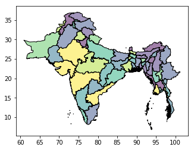

```python
result.plot()
```

## Add Country Shapefiles

```python
Bangladesh_country = gpd.read_file("BGD_adm_shp/BGD_adm0.shp")
Bangladesh_country['coords'] = Bangladesh_country['geometry'].apply(lambda x: x.representative_point().coords[:])
Bangladesh_country['coords'] = [coords[0] for coords in Bangladesh_country['coords']]
Bangladesh_country.head()
```

|  | ACP | AOSIS | ASEAN | Agadir | CACM | CAN | CARICOM | CEEAC | CEMAC | CEPLG | ... | VALIDFR | VALIDTO | WASPARTOF | WBDEBT | WBINCOME | WBOTHER | WBREGION | WWW | geometry | coords |
| --- | --- | --- | --- | --- | --- | --- | --- | --- | --- | --- | --- | --- | --- | --- | --- | --- | --- | --- | --- | --- | --- |
| 0 | 0.0 | 0.0 | 0.0 | 0.0 | 0.0 | 0.0 | 0.0 | 0.0 | 0.0 | 0.0 | ... | 1971 | Present | None | Less indebted | Low income | None | South Asia | None | (POLYGON ((92.27416992187494 20.9261112213137,... | (89.88962116764037, 23.687797546386918) |

1 rows × 69 columns

```python
India_country = gpd.read_file("IND_adm_shp/IND_adm0.shp")
India_country['coords'] = India_country['geometry'].apply(lambda x: x.representative_point().coords[:])
India_country['coords'] = [coords[0] for coords in India_country['coords']]
India_country.head()
```

|  | ACP | AOSIS | ASEAN | Agadir | CACM | CAN | CARICOM | CEEAC | CEMAC | CEPLG | ... | VALIDFR | VALIDTO | WASPARTOF | WBDEBT | WBINCOME | WBOTHER | WBREGION | WWW | geometry | coords |
| --- | --- | --- | --- | --- | --- | --- | --- | --- | --- | --- | --- | --- | --- | --- | --- | --- | --- | --- | --- | --- | --- |
| 0 | 0.0 | 0.0 | 0.0 | 0.0 | 0.0 | 0.0 | 0.0 | 0.0 | 0.0 | 0.0 | ... | Unknown | Present | None | Less indebted | Low income | None | South Asia | None | (POLYGON ((93.78772735595709 6.852640151977823... | (80.22114028499631, 21.788936614990263) |

1 rows × 69 columns

```python
Myanmar_country = gpd.read_file("MMR_adm_shp/MMR_adm0.shp")
Myanmar_country['coords'] = Myanmar_country['geometry'].apply(lambda x: x.representative_point().coords[:])
Myanmar_country['coords'] = [coords[0] for coords in Myanmar_country['coords']]
Myanmar_country.head()
```

|  | ACP | AOSIS | ASEAN | Agadir | CACM | CAN | CARICOM | CEEAC | CEMAC | CEPLG | ... | VALIDFR | VALIDTO | WASPARTOF | WBDEBT | WBINCOME | WBOTHER | WBREGION | WWW | geometry | coords |
| --- | --- | --- | --- | --- | --- | --- | --- | --- | --- | --- | --- | --- | --- | --- | --- | --- | --- | --- | --- | --- | --- |
| 0 | 0.0 | 0.0 | 1.0 | 0.0 | 0.0 | 0.0 | 0.0 | 0.0 | 0.0 | 0.0 | ... | 19370401 | Present | None | Severely indebted | Low income | HIPC | East Asia & Pacific | None | (POLYGON ((97.7991485595706 8.830280303955249,... | (95.92699807713703, 19.25875949859639) |

1 rows × 69 columns

```python
Pakistan_country = gpd.read_file("PAK_adm_shp/PAK_adm0.shp")
Pakistan_country['coords'] = Pakistan_country['geometry'].apply(lambda x: x.representative_point().coords[:])
Pakistan_country['coords'] = [coords[0] for coords in Pakistan_country['coords']]
Pakistan_country.head()
```

|  | ACP | AOSIS | ASEAN | Agadir | CACM | CAN | CARICOM | CEEAC | CEMAC | CEPLG | ... | VALIDFR | VALIDTO | WASPARTOF | WBDEBT | WBINCOME | WBOTHER | WBREGION | WWW | geometry | coords |
| --- | --- | --- | --- | --- | --- | --- | --- | --- | --- | --- | --- | --- | --- | --- | --- | --- | --- | --- | --- | --- | --- |
| 0 | 0.0 | 0.0 | 0.0 | 0.0 | 0.0 | 0.0 | 0.0 | 0.0 | 0.0 | 0.0 | ... | Unknown | Present | None | Moderately indebted | Low income | None | South Asia | None | (POLYGON ((68.07541656494169 23.70541763305675... | (70.17175939277094, 30.47398376464858) |

1 rows × 69 columns

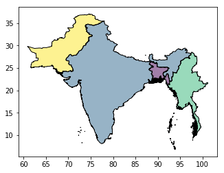

```python
frames_country = [Bangladesh_country, India_country, Myanmar_country, Pakistan_country]
result_country = pd.concat(frames_country)
result_country.plot()
```

# Read Dataframes

## Polity Score

Polity score data frame for coloring in countries:

```python
df1 = pd.read_excel("polity.xlsx")
df1
```

|  | NAME_0 | Polity_score |
| --- | --- | --- |
| 0 | Bangladesh | 0 |
| 1 | India | 9 |
| 2 | Myanmar | 8 |
| 3 | Pakistan | 7 |

Merge with the countries shapefile we just edited:

```python
polity_merge = result.merge(df1, on='NAME_0', how='left')
polity_merge.head()
```

|  | CCA_1 | CCN_1 | ENGTYPE_1 | HASC_1 | ID_0 | ID_1 | ISO | NAME_0 | NAME_1 | NL_NAME_1 | TYPE_1 | VARNAME_1 | geometry | coords | Polity_score |
| --- | --- | --- | --- | --- | --- | --- | --- | --- | --- | --- | --- | --- | --- | --- | --- |
| 0 | None | 0 | Division | BD.BA | 20 | 1 | BGD | Bangladesh | Barisal | None | Bibhag | Bakerganj | (POLYGON ((90.59583282470732 21.73779106140142... | (90.08694673254791, 22.507297515869226) | 0 |
| 1 | None | 0 | Division | BD.CG | 20 | 2 | BGD | Bangladesh | Chittagong | None | Bibhag | Chattagram\|Parbattya Chattagram\|Rangamati | (POLYGON ((92.27416992187494 20.92611122131353... | (92.12255656808205, 22.505138397216825) | 0 |
| 2 | None | 0 | Division | BD.DA | 20 | 3 | BGD | Bangladesh | Dhaka | None | Bibhag | Daca\|Dacca | (POLYGON ((90.53539276123075 23.05745887756359... | (90.41773081695224, 24.12462520599368) | 0 |
| 3 | None | 0 | Division | BD.KH | 20 | 4 | BGD | Bangladesh | Khulna | None | Bibhag | None | (POLYGON ((89.23109436035179 21.70012092590338... | (89.33294352171342, 23.145980834960938) | 0 |
| 4 | None | 0 | Division | BD.RS | 20 | 5 | BGD | Bangladesh | Rajshahi | None | Bibhag | None | POLYGON ((88.99384307861334 25.27587127685558,... | (88.93052378483573, 24.538715362548885) | 0 |

## Armed Groups

Import dataframe for terminated and non-terminated groups.

```python
terminated = pd.read_excel("Terminated.xlsx", usecols = [3, 4, 5, 7, 9, 10, 12, 13, 22, 25])
terminated.head()
```

|  | stateprovince | Longitude | Latitude | fullname | startdate | obsyear | terminateform | armedorder | aggoals | polpar |
| --- | --- | --- | --- | --- | --- | --- | --- | --- | --- | --- |
| 0 | Andhra Pradesh | 82.247465 | 16.989065 | People's War Group | 1980 | 2004 | incorporation | containment | control over central government | non-participation |
| 1 | Assam | 92.937574 | 26.200604 | United People's Democratic Solidarty | 1999 | 2011 | incorporation | limited cooperation | autonomy short of secession | non-participation |
| 2 | Assam | 92.937574 | 26.200604 | All Bodo Student Union | 1989 | 1993 | incorporation | unknown | autonomy short of secession | non-participation |
| 3 | Assam | 92.937574 | 26.200604 | Bodo Liberation Tigers Force | 1996 | 2003 | incorporation | unknown | autonomy short of secession | informal advocacy |
| 4 | Assam | 94.224298 | 27.001617 | Dimasa National Security Force | 1992 | 1995 | collapse | containment | autonomy short of secession | non-participation |

```python
not_terminated = pd.read_excel("Not_terminated.xlsx", usecols = [3, 4, 5, 7, 9, 11, 13, 16, 18, 22, 25])
not_terminated.head()
```

|  | stateprovince | Longitude | Latitude | fullname | startdate | terminate | armedorder | peacedealongoing | ceasefireongoing | aggoals | polpar |
| --- | --- | --- | --- | --- | --- | --- | --- | --- | --- | --- | --- |
| 0 | National | 90.356331 | 23.684994 | Jatiya Samajtantrik Dal | 1972 | Not terminated | containment | no | no | control over central government | formal participation |
| 1 | National | 90.412518 | 23.784994 | Jatiyo Rakkhi Bahini | 1972 | Not terminated | containment | no | no | control over central government | formal participation |
| 2 | Andhra Pradesh | 79.939988 | 16.912900 | Revolutionary Communist Committee | 1968 | Not terminated | total war | no | no | control over central government | non-participation |
| 3 | Andhra Pradesh | 79.419179 | 13.628756 | Communist Party of India (Marxist - Leninist) | 1968 | Not terminated | total war | no | no | control over central government | non-participation |
| 4 | Andhra Pradesh | 81.095243 | 16.710660 | Communist Party of India (Revolutionaries) | 1972 | Not terminated | containment | no | no | control over central government | non-participation |

## Writing GeoDataframe as a shapefile

This is not necessary for this project, but if you want to write a GeoDataframe as a shapefile, below is how to do it. Let's use another dataset for all groups (terminated and not terminated), and call it groups_df.

First, zip the longitude and latitude into one column called "geometry".

```python
from shapely.geometry import Point

groups_df = pd.read_excel("AOSA_map.xls")
geometry = [Point(xy) for xy in zip(groups_df.Longitude, groups_df.Latitude)]
groups_coords = gpd.GeoDataFrame(groups_df, crs = result.crs, geometry=geometry)

groups_coords['geometry'] = groups_coords.apply(lambda x: Point((float(x.Longitude), float(x.Latitude))), axis=1)
groups_coords.head()
```

|  | UCDPConflictID | Country | context | stateprovince | Longitude | Latitude | agname | fullname | actor_ID | startdate | ... | polpar | pargov | polity_score | regime_change | number_regime_change | leadership_tur0ver | number_leadership_tur0ver | national_election | stateprovince_election | geometry |
| --- | --- | --- | --- | --- | --- | --- | --- | --- | --- | --- | --- | --- | --- | --- | --- | --- | --- | --- | --- | --- | --- |
| 0 | NaN | Bangladesh | National | NaN | 90.356331 | 23.684994 | JSD | Jatiya Samajtantrik Dal | NaN | 1972.0 | ... | 3 | 0 | -7.0 | 0 | 0.0 | 1 | 1.0 | 0 | -999 | POINT (90.356331 23.684994) |
| 1 | NaN | Bangladesh | National | NaN | 90.412518 | 23.784994 | JRB | Jatiyo Rakkhi Bahini | NaN | 1972.0 | ... | 3 | 0 | -7.0 | 1 | 1.0 | 1 | 1.0 | 0 | -999 | POINT (90.4125181 23.784994) |
| 2 | NaN | India | Naxal | Andhra Pradesh | 79.939988 | 16.912900 | RCC | Revolutionary Communist Committee | NaN | 1968.0 | ... | 0 | 3 | 9.0 | 0 | 0.0 | 0 | 0.0 | 1 | 0 | POINT (79.9399875 16.9128998) |
| 3 | NaN | India | Naxal | Andhra Pradesh | 79.419179 | 13.628756 | CPI-ML (Andhra) | Communist Party of India (Marxist - Leninist) | 192.0 | 1968.0 | ... | 0 | 2 | 9.0 | 0 | 0.0 | 0 | 0.0 | 0 | 0 | POINT (79.4191795 13.6287557) |
| 4 | 1-29 | India | Naxal | Andhra Pradesh | 82.247465 | 16.989065 | PWG | People's War Group | 193.0 | 1980.0 | ... | 0 | 3 | 9.0 | 0 | 0.0 | 1 | 1.0 | 1 | 1 | POINT (82.2474648 16.9890648) |

5 rows × 35 columns

See what the datapoints look like:

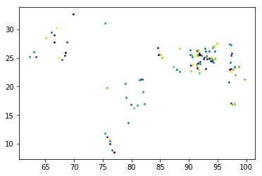

```python
groups_coords.plot()
```

Looks right. Convert the dataframe into a GeoDataframe with geopandas (gpd) and write as a shapefile.

```python
groups_coords = gpd.GeoDataFrame(groups_coords, geometry='geometry')
groups_coords.to_file('Groups.shp', driver='ESRI Shapefile')
```

# Mapping

Using folium, make a basemap that starts at 24, 84 for latlong and start at zoom level 5. Ask folium to create a choropleth map on the field "Polity_score", using the Yellow Green color scheme. Caption the legend "Polity Score Scale". Read the terminated groups and non-terminated groups dataframes, and using for-loops, add as markers to the map.

```python
import folium
from folium.element import IFrame
from geopy.geocoders import Nominatim


m = folium.Map([24, 84],
               zoom_start=5)

folium.TileLayer('Mapbox Bright').add_to(m)

ft = "Polity_score"
cmap = folium.colormap.linear.YlGn.to_step(9).scale(polity_merge[ft].min(), polity_merge[ft].max())

folium.GeoJson(polity_merge,
               style_function=lambda feature: {
                'fillColor': cmap(feature['properties'][ft]),
                'fillOpacity' : 0.95,
                'weight' : 1, 'color' : 'black'
               }).add_to(m)

cmap.caption = 'Polity Score Scale'
cmap.add_to(m)

folium.GeoJson(result_country,
               style_function=lambda feature: {'weight': 2, 'color':'black'}).add_to(m)

terminated_groups = terminated
terminated_groups["fullname"] = terminated_groups["fullname"].astype(str)

not_terminated_groups = not_terminated
not_terminated_groups["fullname"] = not_terminated_groups["fullname"].astype(str)

#my_marker_cluster = folium.MarkerCluster().add_to(m)
for ix, row in terminated_groups.iterrows():
    folium.CircleMarker(location = [row['Latitude'],row['Longitude']], radius=5000, popup=row['fullname']
                        + ", formed in " + str(row['startdate'])
                        + ", terminated in " + str(row['obsyear'])
                        + " with " + str(row['terminateform'])
                        + ". Armed order was " + str(row['armedorder'])
                        + ". Group goal was " + str(row['aggoals'])
                        + ". Political participation status was " + str(row['polpar']) + ".", color='#FF0000', fill_color='#FF0000').add_to(m)
for ix, row in not_terminated_groups.iterrows():
    folium.CircleMarker(location = [row['Latitude'],row['Longitude']], radius=5000, popup=row['fullname']
                        + ", formation year " + str(row['startdate'])
                        + ". " + str(row['terminate']) + ". There is " + str(row['ceasefireongoing']) + " ongoing ceasefire, "
                        + "and " + str(row['peacedealongoing']) + " ongoing peacedeal"
                        + ". Armed order is " + str(row['armedorder'])
                        + ". Group goal is " + str(row['aggoals'])
                        + ". Political participation status is " + str(row['polpar']) + ".", color='#00FF00', fill_color='#00FF00').add_to(m)


m.save("HeatMap.html")
m
```

Another way of doing a choropleth map allows you to set your own color scheme. First define a stepped color scheme either using hex codes or color names. Then use that stepped color scheme to map out the variable polity_score.

```python
import folium
from folium.element import IFrame
from geopy.geocoders import Nominatim
import folium.colormap as cm

step = cm.StepColormap(['#AED6F1', '#3498DB', '#2874A6', '#1B4F72'], vmin=0., vmax=9., index=[0,6,7,8,9], caption='Polity Score')
step

m = folium.Map([24, 84], tiles='cartodbpositron', zoom_start=5)

ft='Polity_score'

folium.GeoJson(polity_merge,
               style_function=lambda feature: {
                'fillColor': step(feature['properties'][ft]),
                'fillOpacity' : 0.95,
                'weight' : 1, 'color' : 'white'
               }).add_to(m)

step.add_to(m)

folium.GeoJson(result_country,
               style_function=lambda feature: {'weight': 3, 'color':'black'}).add_to(m)

terminated_groups = terminated
terminated_groups["fullname"] = terminated_groups["fullname"].astype(str)

not_terminated_groups = not_terminated
not_terminated_groups["fullname"] = not_terminated_groups["fullname"].astype(str)

#my_marker_cluster = folium.MarkerCluster().add_to(m)
for ix, row in terminated_groups.iterrows():
    folium.CircleMarker(location = [row['Latitude'],row['Longitude']], radius=5000, popup=row['fullname']
                        + ", formed in " + str(row['startdate'])
                        + ", terminated in " + str(row['obsyear'])
                        + " with " + str(row['terminateform'])
                        + ". Armed order was " + str(row['armedorder'])
                        + ". Group goal was " + str(row['aggoals'])
                        + ". Political participation status was " + str(row['polpar']) + ".", color='#FF0000', fill_color='#FF0000').add_to(m)
for ix, row in not_terminated_groups.iterrows():
    folium.CircleMarker(location = [row['Latitude'],row['Longitude']], radius=5000, popup=row['fullname']
                        + ", formation year " + str(row['startdate'])
                        + ". " + str(row['terminate']) + ". There is " + str(row['ceasefireongoing']) + " ongoing ceasefire, "
                        + "and " + str(row['peacedealongoing']) + " ongoing peacedeal"
                        + ". Armed order is " + str(row['armedorder'])
                        + ". Group goal is " + str(row['aggoals'])
                        + ". Political participation status is " + str(row['polpar']) + ".", color='#00FF00', fill_color='#00FF00').add_to(m)


m.save("HeatMap2.html")
m
```